# Data Science Capstone - Word Prediction App

Amit Kohli  
April 18, 2016

### Capstone Objective

1. Using a freely downloadable English text corpus, build a **Predictive Text Model** that takes in sentence fragments as input and output prediction of the **next word**.
2. The training corpus is sampled from HC Corpora which comprises 102 million words & 7 million English sentences taken from 3 online sources namely Blogs, News and Tweets.
3. The model uses conditional probability. In the example of a 2-gram, if the first word is *Good*, it looks for the probability that the next word would be *Morning* using the following formula. \[ P(\mbox{Morning}|\mbox{Good}) = \frac{P(\mbox{Good Morning})}{P(\mbox{Good})} \]
4. The model searches a dataset consisting of 1-grams, 2-grams, 3-grams and 4-grams.
5. Develop interactive Shiny Application to demonstrate capabilities of the predictive alogrithm

### Method

**Katz's backoff**

\( P_{Katz}(w_{i}\mid w_{i-n+1}^{i-1}) = \)

\[ \begin{cases} d \cdot P_{MLE}(w_{i}\mid w_{i-n+1}^{i-1}) \\ _{\text{if } C(w_{i-n+1}^{i})>0} \\ \\ \lambda \cdot P_{Katz}(w_{i}\mid w_{i-n+1}^{i-2}) \\ _{\text{otherwise}} \end{cases} \]

- Maximum Likelihood Estimate (MLE):  
  Count of n-gram divided by total count across all n-grams having the same context
- d = discount factor
- λ = probability mass shifted
- Uses discounted MLE for observed n-grams. Backoff to smaller n-gram for n-grams not observed in training

**Kneser-Ney** (Interpolation) \[ \begin{align*}P_{KN}(w_{i}\mid w_{i-n+1}^{i-1}) &= \frac{C(w_{i-n+1}^{i})-D}{\sum_{w_{i}}C(w_{i-n+1}^{i})} \\ &+ \lambda \cdot P_{KN}(w_{i}\mid w_{i-n+1}^{i-2}) \end{align*} \]

\( \text{where } C(w_{i-n+1}^{i}) = \)

\[ \begin{cases} \text{freq count} & _{\text{highest order}} \\ \text{N(unique histories)} & _{\text{lower orders}} \end{cases} \]

- Count is discounted to shift some probability mass to lower-order model for interpolation
- Probability estimate of lower-order n-grams obtained by counting no. of unique histories instead of taking MLE

### Performance

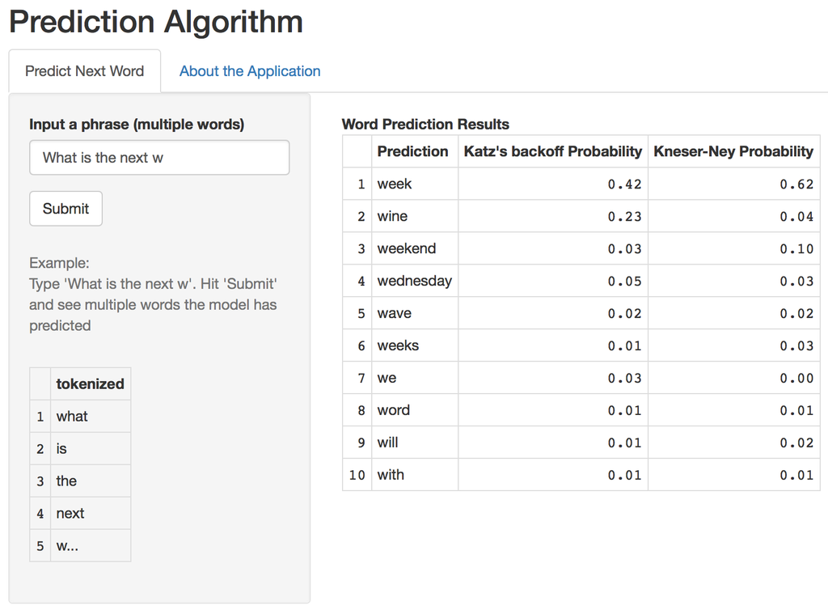

### The Learning Model

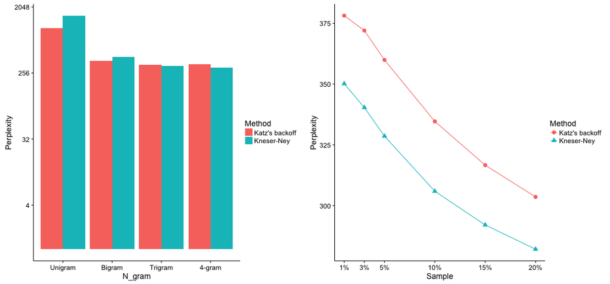